Curso R - Aula 1 Dennis Leão março 15, 2019

# R Básico

Variáveis não são nada além de um nome para um local da memória contendo um valor. Uma variável em R pode armazenar valores numéricos, valores complexos, palavras, matrizes e até uma tabela.

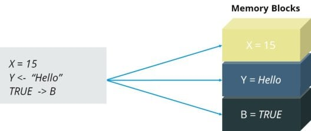

Em R, não precisamos declarar uma variável antes de usá-la, ao contrário de outras linguagens de programação, como Java, C, C ++ etc.

Em R, uma variável em si não é declarada de nenhum tipo de dados, mas obtém o tipo de dados do objeto R atribuído a ela. Então R é chamado de linguagem tipada dinamicamente, o que significa que podemos mudar um tipo de dados da mesma variável de novo e de novo ao usá-la em um programa.

Tipos de dados especifica qual tipo de valor uma variável possui e que tipo de operações matemáticas, relacionais ou lógicas podem ser aplicadas a ela sem causar um erro. Existem muitos tipos de dados em R, mas abaixo estão os mais usados:

### Configuração inicial do diretório de trabalho

- O diretório de trabalho é uma pasta onde o R será direcionado. Todos os arquivos que serão importados (base de dados, …) ou exportados (base de dados, gráficos, …) por ele deverão ficar nesta pasta.
- Existem duas maneiras de configurar o diretório de trabalho (suponha que vamos usar a pasta ~/R_basico):
1. Utilizando a função setwd() dentro do R:

```r
setwd("~/R_basico")
```

2. Confira o diretório que está trabalhando com a função:

```r
getwd()
```

```
## [1] "/home/dennis/Desktop"
```

## Objetos

O que é um objeto?

- Um símbolo ou uma variável capaz de armazenar qualquer valor ou estrutura de dados

Por quê objetos?

- Uma maneira simples de acessar os dados armazenados na memória (o R não permite acesso direto à memória)

Programação:

- Objetos ⇒ Classes ⇒ Métodos
- Classe: é a definição de um objeto. Descreve a forma do objeto e como ele será manipulado pelas diferentes funções
- Método: são funções genéricas que executam suas tarefas de acordo com cada classe. As funções genéricas mais importantes são: summary() e plot()

Veja o resultado de

```r
methods(summary)
methods(plot)
```

## Nomes de objetos

- Podem ser formados por letras, números, “_”, e “.”
- Não podem começar com número e/ou ponto
- Não podem conter espaços
- Evite usar acentos
- Evite usar nomes de funções como:

```r
c q t C D F I T diff df data var pt
```

- O R é case-sensitive, portanto:

```r
dados ≠ Dados ≠ DADOS
```

## Gerenciando a área de trabalho

Liste os objetos criados com a função ls():

```r
ls()
```

Para remover apenas um objeto:

```r
rm(x)
```

Para remover outros objetos:

```r
rm(x, y)
```

Para remover todos os objetos:

```r
rm(list = ls())
```

### Exercícios

# Tipo de estruturas de Dados.

Tipos de Variáveis presentes em linguaguem R.

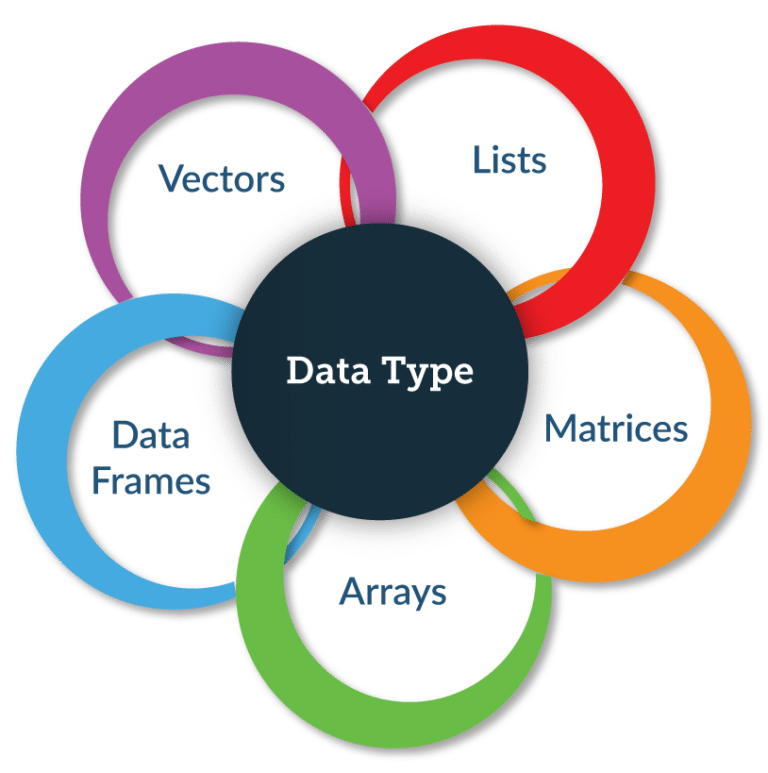

[figure not shown]

## Vetores

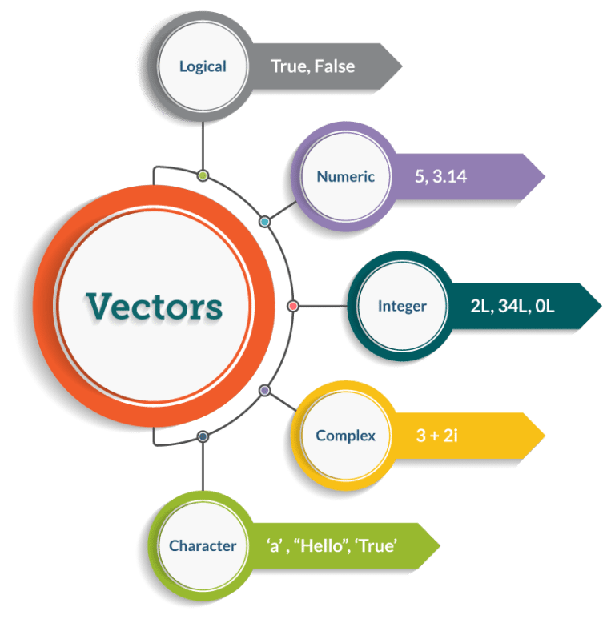

- Logical: É usado para armazenar valores Booleanos como TRUE ou FALSE.
- Numeric: É usado para armazenar valores tanto positivos como negativos númericos reais.
- Integer: É usado para armazenar valores númericos inteiros como positivos e negativos.
- Complex: É usado para armazenar valores númericos imaginários sendo i igual a raíz de -1.
- Character: É usado para armazenar valores tanto como characteres simples, grupos de characteres(palavras) ou qualquer outro tipo de string. São definidos por aspas simples ou duplas.

Características:

- Coleção ordenada de valores
- Estrutura unidimensional

Usando a função c() para criar vetores:

```r
num <- c(10, 5, 2, 4, 8, 9)
num
```

```
## [1] 10  5  2  4  8  9
```

```r
class(num)
```

```
## [1] "numeric"
```

Por que numeric e não integer?

```r
x <- c(10L, 5L, 2L, 4L, 8L, 9L)
x
```

```
## [1] 10  5  2  4  8  9
```

```r
class(x)
```

```
## [1] "integer"
```

Para forçar a representação de um número para inteiro é necessário usar o sufixo L.

Note que a diferença entre numeric e integer também possui impacto computacional, pois o armazenamento de números inteiros ocupa menos espaço na memória. Dessa forma, esperamos que o vetor x acima ocupe menos espaço na memória do que o vetor num, embora sejam aparentemente idênticos. Veja:

```r
object.size(num)
```

```
## 96 bytes
```

```r
object.size(x)
```

```
## 80 bytes
```

A diferença pode parecer pequena, mas pode ter um grande impacto computacional quando os vetores são formados por milhares ou milhões de números.

**Um vetor só pode conter elementos de uma mesma classe.**

**(A única excessão é a lista)**

### Operações matemáticas em vetores

Operações podem ser feitas entre um vetor e um número:

```r
num * 2
```

```
## [1] 20 10  4  8 16 18
```

E também entre vetores de mesmo comprimento ou com comprimentos múltiplos:

```r
num * num
```

```
## [1] 100  25   4  16  64  81
```

```r
num + c(2, 4, 1)
```

```
## [1] 12  9  3  6 12 10
```

### A Regra da Reciclagem

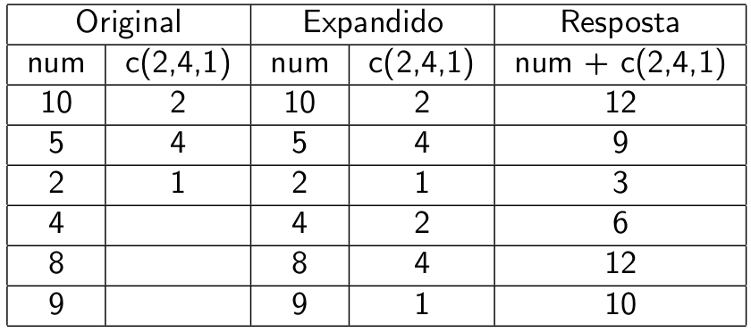

Agora tente:

```r
num + c(2, 4, 1, 3)
```

### Exercícios

1. Crie um objeto com os valores 54, 0, 17, 94, 12.5, 2, 0.9, 15.
2. Some o objeto acima com os valores 5, 6.

### Outras classes de vetores

Vetores também podem ter outras classes:

- Vetor de caracteres:

```r
caracter <- c("brava", "joaquina", "armação")
caracter
```

```
## [1] "brava"    "joaquina" "armação"
```

- Vetor lógico:

```r
logico <- caracter == "armação"
logico
```

```
## [1] FALSE FALSE  TRUE
```

ou

```r
logico <- num > 4
logico
```

```
## [1]  TRUE  TRUE FALSE FALSE  TRUE  TRUE
```

No exemplo anterior, a condição num > 4 é uma expressão condicional, e o símbolo > um operador lógico. Veremos nos próximos tópicos esses operadores e suas propriedades.

### Fator

Características:

- Coleção de categorias ou níveis (levels)
- Estrutura unidimensional

Utilizando as funções factor() e c():

```r
fator <- factor(c("alta","baixa","baixa","media",
                  "alta","media","baixa","media","media"))
fator
```

```
## [1] alta  baixa baixa media alta  media baixa media media
## Levels: alta baixa media
```

```r
class(fator)
```

```
## [1] "factor"
```

Caso haja uma hierarquia, os níveis dos fatores podem ser ordenados:

```r
fator <- factor(c("alta","baixa","baixa","media",
                  "alta","media","baixa","media","media"),
                levels = c("alta","media","baixa"))
fator
```

```
## [1] alta  baixa baixa media alta  media baixa media media
## Levels: alta media baixa
```

### Exercicios

1. Construa um único objeto com as letras: A, B, e C, repetidas cada uma 15, 12, e 8 vezes, respectivamente.
2. Mostre na tela, em forma de verdadeiro ou falso, onde estão as letras B nesse objeto.
3. Veja a página de ajuda da função sum() e descubra como fazer para contar o número de letras B neste vetor (usando sum()).
4. Crie um objeto com 100 valores aleatórios de uma distribuição uniforme U(0,1). Conte quantas vezes aparecem valores maiores ou iguais a 0,5.

### Misturando classes de objetos

Algumas vezes isso acontece por acidente, mas também pode acontecer de propósito.

O que acontece aqui?

```r
w <- c(5L, "a")
x <- c(1.7, "a")
y <- c(TRUE, 2)
z <- c("a", T)
```

Lembre-se da regra:

**“Um vetor só pode conter elementos de uma mesma classe.”**

Quando objetos de diferentes classes são misturados, ocorre a coerção, para que cada elemento possua a mesma classe.

Nos exemplos acima, nós vemos o efeito da coerção implícita, quando o R tenta representar todos os objetos de uma única forma.

Nós podemos forçar um objeto a mudar de classe, através da coerção explícita, realizada pelas funções as.*:

```r
x <- 0:6
class(x)
```

```
## [1] "integer"
```

```r
as.numeric(x)
```

```
## [1] 0 1 2 3 4 5 6
```

```r
as.logical(x)
```

```
## [1] FALSE  TRUE  TRUE  TRUE  TRUE  TRUE  TRUE
```

```r
as.character(x)
```

```
## [1] "0" "1" "2" "3" "4" "5" "6"
```

```r
as.factor(x)
```

```
## [1] 0 1 2 3 4 5 6
## Levels: 0 1 2 3 4 5 6
```

```r
(x <- c(FALSE, TRUE))
```

```
## [1] FALSE  TRUE
```

```r
class(x)
```

```
## [1] "logical"
```

```r
as.numeric(x)
```

```
## [1] 0 1
```

Algumas vezes não é possível fazer a coerção, então:

```r
x <- c("a", "b", "c")
as.numeric(x)
```

```
## [1] NA NA NA
```

```r
as.logical(x)
```

```
## [1] NA NA NA
```

### Valores perdidos e especiais

Valores perdidos devem ser definidos como NA (not available):

```r
perd <- c(3, 5, NA, 2)
perd
```

```
## [1]  3  5 NA  2
```

```r
class(perd)
```

```
## [1] "numeric"
```

Podemos testar a presença de NAs com a função is.na():

```r
is.na(perd)
```

```
## [1] FALSE FALSE  TRUE FALSE
```

Ou:

```r
any(is.na(perd))
```

```
## [1] TRUE
```

Outros valores especiais são:

- NaN (not a number) - exemplo: 0/0
- -Inf e Inf - exemplo: 1/0

A função is.na() também testa a presença de NaNs:

```r
perd <- c(-1,0,1)/0
perd
```

```
## [1] -Inf  NaN  Inf
```

```r
is.na(perd)
```

```
## [1] FALSE  TRUE FALSE
```

A função is.infinite() testa se há valores infinitos

```r
is.infinite(perd)
```

```
## [1]  TRUE FALSE  TRUE
```

## Listas

As listas são bastante semelhantes aos vetores, mas as listas são os objetos R que podem conter elementos de diferentes tipos como - números, seqüências de caracteres, vetores e outra lista dentro delas.

Características:

- Pode combinar uma coleção de objetos de diferentes classes (é um tipo especial de vetor)
- Estrutura “unidimensional”: apenas o número de elementos é contado

Utilizando a função list():

```r
lista <- list(a = 1:10, b = c("T1", "T2", "T3", "T4"), TRUE, 2 + 2)
lista
```

```
## $a
##  [1]  1  2  3  4  5  6  7  8  9 10
##
## $b
## [1] "T1" "T2" "T3" "T4"
##
## [[3]]
## [1] TRUE
##
## [[4]]
## [1] 4
```

```r
class(lista)
```

```
## [1] "list"
```

```r
dim(lista)
```

```r
length(lista)
```

```
## [1] 4
```

Formando uma lista com objetos criados anteriormente:

[output not shown]

[output not shown]

```r
lista <- list(fator = fator, matriz = matriz)
lista
```

```
## $fator
## [1] alta  baixa baixa media alta  media baixa media media
## Levels: alta baixa media
##
## $matriz
##      [,1] [,2] [,3] [,4]
## [1,]    1    4    7   10
## [2,]    2    5    8   11
## [3,]    3    6    9   12
```

```r
length(lista)
```

```
## [1] 2
```

## Matrix

Matriz é o objeto R no qual os elementos são organizados em um layout retangular bidimensional.

A sintaxe básica para criar uma matriz em R é:

```r
matrix(data, nrow, ncol, byrow, dimnames)
```

Onde

- data é o vetor de entrada que se torna os elementos de dados da matriz.
- nrow é o número de linhas a serem criadas.
- ncol é o número de colunas a serem criadas.
- byrow é uma pista lógica. Se TRUE, os elementos do vetor de entrada são organizados por linha.
- dimname é o nome atribuído às linhas e colunas.
- exemplo:

```r
matriz <- matrix(1:12, nrow = 3, ncol = 4)
matriz
```

```
##      [,1] [,2] [,3] [,4]
## [1,]    1    4    7   10
## [2,]    2    5    8   11
## [3,]    3    6    9   12
```

```r
class(matriz)
```

```
## [1] "matrix"
```

Alterando a ordem de preenchimento da matriz (por linhas):

```r
matriz <- matrix(1:12, nrow = 3, ncol = 4, byrow = TRUE)
matriz
```

```
##      [,1] [,2] [,3] [,4]
## [1,]    1    2    3    4
## [2,]    5    6    7    8
## [3,]    9   10   11   12
```

Para verificar a dimensão da matriz:

```r
dim(matriz)
```

```
## [1] 3 4
```

Adicionando colunas com cbind()

```r
cbind(matriz, rep(99, 3))
```

```
##      [,1] [,2] [,3] [,4] [,5]
## [1,]    1    2    3    4   99
## [2,]    5    6    7    8   99
## [3,]    9   10   11   12   99
```

Adicionando linhas com rbind()

```r
rbind(matriz, rep(99, 4))
```

```
##      [,1] [,2] [,3] [,4]
## [1,]    1    2    3    4
## [2,]    5    6    7    8
## [3,]    9   10   11   12
## [4,]   99   99   99   99
```

Matrizes também podem ser criadas a partir de vetores adicionando um atributo de dimensão

```r
m <- 1:10
m
```

```
##  [1]  1  2  3  4  5  6  7  8  9 10
```

```r
class(m)
```

```
## [1] "integer"
```

```r
dim(m)
```

```r
dim(m) <- c(2, 5)
m
```

```
##      [,1] [,2] [,3] [,4] [,5]
## [1,]    1    3    5    7    9
## [2,]    2    4    6    8   10
```

```r
class(m)
```

```
## [1] "matrix"
```

### Operações matemáticas em matrizes

Matriz multiplicada por um escalar

```r
matriz * 2
```

```
##      [,1] [,2] [,3] [,4]
## [1,]    2    4    6    8
## [2,]   10   12   14   16
## [3,]   18   20   22   24
```

Multiplicação de matrizes (observe as dimensões!)

```r
matriz2 <- matrix(1, nrow = 4, ncol = 3)
matriz %*% matriz2
```

```
##      [,1] [,2] [,3]
## [1,]   10   10   10
## [2,]   26   26   26
## [3,]   42   42   42
```

## Array

Arrays em R são objetos de dados que podem ser usados para armazenar dados em mais de duas dimensões. Leva vetores como entrada e usa os valores no parâmetro de dimensão para criar um Array.

A sintaxe básica para criar um array em R é:

```r
array(data, dim, dimnames)
```

Onde:

- data é o vetor de entrada que se torna os elementos de dados da matriz.
- dim é a dimensão da matriz, onde você passa o número de linhas, colunas e o número de matrizes a serem criadas pelas dimensões mencionadas.
- dimname é o nome atribuído às linhas e colunas.

Exemplo:

```r
array <- array( c(1:16), dim=c(4,4,4))
array
```

```
## , , 1
##
##      [,1] [,2] [,3] [,4]
## [1,]    1    5    9   13
## [2,]    2    6   10   14
## [3,]    3    7   11   15
## [4,]    4    8   12   16
##
## , , 2
##
##      [,1] [,2] [,3] [,4]
## [1,]    1    5    9   13
## [2,]    2    6   10   14
## [3,]    3    7   11   15
## [4,]    4    8   12   16
##
## , , 3
##
##      [,1] [,2] [,3] [,4]
## [1,]    1    5    9   13
## [2,]    2    6   10   14
## [3,]    3    7   11   15
## [4,]    4    8   12   16
##
## , , 4
##
##      [,1] [,2] [,3] [,4]
## [1,]    1    5    9   13
## [2,]    2    6   10   14
## [3,]    3    7   11   15
## [4,]    4    8   12   16
```

## Data Frame

Um Data Frame é uma tabela ou uma estrutura parecida com uma matriz bidimensional na qual cada coluna contém valores de uma variável e cada linha contém um conjunto de valores para cada coluna. Abaixo estão algumas das características de um Data Frame que precisa ser considerado toda vez que trabalhamos com eles:

- Os nomes das colunas devem estar não vazios.
- Cada coluna deve conter a mesma quantidade de itens de dados.
- Os dados armazenados em um quadro de dados podem ser de tipo numérico, de fator ou de caractere.
- Os nomes das linhas devem ser exclusivos.

Características:

- Uma lista de vetores e/ou fatores, de mesmo comprimento
- Pode conter diferentes tipos de dados (numérico, fator, …)
- Estrutura bidimensional

Utilizando a função data.frame():

```r
da <- data.frame(ano = 2000:2004,
                 prod = c(32, 54, 25, 48, 29))
da
```

```
##    ano prod
## 1 2000   32
## 2 2001   54
## 3 2002   25
## 4 2003   48
## 5 2004   29
```

```r
class(da)
```

```
## [1] "data.frame"
```

```r
dim(da)
```

```
## [1] 5 2
```

```r
length(num)
```

```
## [1] 6
```

```r
length(fator)
```

```
## [1] 9
```

```r
da <- data.frame(numerico = c(num, NA, NA, NA),
                        fator = fator)
da
```

```
##   numerico fator
## 1       10  alta
## 2        5 baixa
## 3        2 baixa
## 4        4 media
## 5        8  alta
## 6        9 media
## 7       NA baixa
## 8       NA media
## 9       NA media
```

```r
class(da)
```

```
## [1] "data.frame"
```

```r
dim(da)
```

```
## [1] 9 2
```

```r
str(da)
```

```
## 'data.frame':    9 obs. of  2 variables:
##  $ numerico: num  10 5 2 4 8 9 NA NA NA
##  $ fator   : Factor w/ 3 levels "alta","baixa",..: 1 2 2 3 1 3 2 3 3
```

**A função str() é uma das que você precisa saber!**

Para converter um data frame para uma matriz

```r
as.matrix(da)
```

```
##       numerico fator
##  [1,] "10"     "alta"
##  [2,] " 5"     "baixa"
##  [3,] " 2"     "baixa"
##  [4,] " 4"     "media"
##  [5,] " 8"     "alta"
##  [6,] " 9"     "media"
##  [7,] NA       "baixa"
##  [8,] NA       "media"
##  [9,] NA       "media"
```

### Nomes (atributo)

bjetos do R podem ter nomes, que facilitam a auto-descrição

```r
x <- 1:3
names(x)
```

```r
names(x) <- c("Curitiba", "Paraná", "Brasil")
x
```

```
## Curitiba   Paraná   Brasil
##        1        2        3
```

```r
names(x)
```

```
## [1] "Curitiba" "Paraná"   "Brasil"
```

Listas também podem ter nomes

```r
x <- list(Curitiba = 1, Paraná = 2, Brasil = 3)
x
```

```
## $Curitiba
## [1] 1
##
## $Paraná
## [1] 2
##
## $Brasil
## [1] 3
```

```r
names(x)
```

```
## [1] "Curitiba" "Paraná"   "Brasil"
```

Associando nomes às linhas e colunas de uma matriz:

```r
rownames(matriz) <- c("A","B","C")
colnames(matriz) <- c("T1","T2","T3","T4")
matriz
```

```
##   T1 T2 T3 T4
## A  1  2  3  4
## B  5  6  7  8
## C  9 10 11 12
```

Para data frames existe uma função especial para os nomes de linhas, row.names(). Data frames também não possuem nomes de colunas, apenas nomes, já que é um caso particular de lista. Então para verificar/alterar nomes de colunas de um data frame também use names().

```r
names(da)
```

```
## [1] "numerico" "fator"
```

```r
row.names(da)
```

```
## [1] "1" "2" "3" "4" "5" "6" "7" "8" "9"
```

Um resumo das funções para alterar/acessar nomes de linhas e colunas em matrizes e data frames.

Classe:

- **data.frame** :

Nome da colunas: names()

Nome das linhas: row.names()

Classe:

- **matrix** :

Nome da colunas: colnames()

Nome das linhas: rownames()

Exercícios:

1. Crie um objeto para armazenar a seguinte matriz

$$\left[ \begin{array} { c c c } { 2 } & { 8 } & { 4 } \\ { 0 } & { 4 } & { 1 } \\ { 9 } & { 7 } & { 5 } \end{array} \right]$$

2. Atribua nomes para as linhas e colunas dessa matriz.
3. Crie uma lista (não nomeada) com dois componentes: (1) um vetor com as letras A, B, e C, repetidas 2, 5, e 4 vezes respectivamente; e (2) a matriz do exemplo anterior.
4. Atribua nomes para estes dois componentes da lista.
5. Inclua mais um componente nesta lista, com o nome de fator, e que seja um vetor da classe fator, idêntico ao objeto caracter criado acima (que possui apenas os nomes brava, joaquina, armação).
6. Você contou 42 caranguejos na Joaquina, 34 no Campeche, 59 na Armação, e 18 na Praia Mole. Crie um data frame para armazenar estas informações (número de caranguejos observados e local).

# Operadores

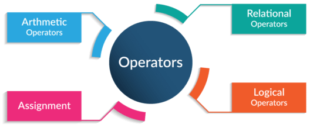

## Operadores Aritméticos

Esses operadores nos ajudam a executar as operações aritméticas básicas, como adição, subtração, multiplicação etc.

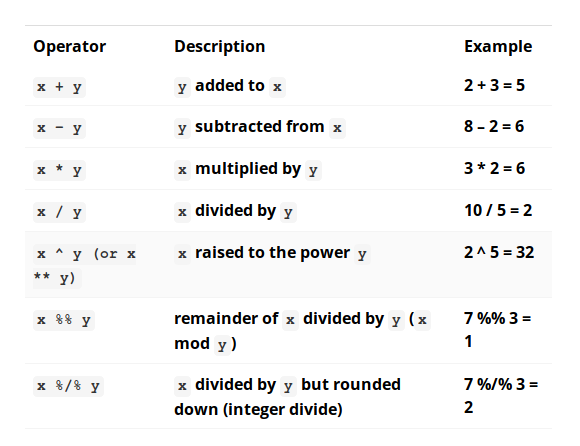

### Ordem de Execução

As operações são realizadas sempre seguindo as prioridades:

- De dentro para fora de parênteses ()
- Multiplicação e divisão
- Adição e subtração

```r
 5 * 2 - 10 + 7
```

```
## [1] 7
```

```r
5 * 2 - (10 + 7)
```

```
## [1] -7
```

```r
5 * (2 - 10 + 7)
```

```
## [1] -5
```

```r
5 * (2 - (10 + 7))
```

```
## [1] -75
```

Exemplo dos Operadores

```r
num1 = 15
num2 = 20
num3 = 0
#addition
num3 = num1 + num2
num3
```

```
## [1] 35
```

```r
#substraction
num3 = num1 - num2
num3
```

```
## [1] -5
```

```r
#multiplication
num3= num1 * num2
num3
```

```
## [1] 300
```

```r
#division
num3 = num1 / num2
num3
```

```
## [1] 0.75
```

```r
#modulus
num3 = num1 %% num2
num3
```

```
## [1] 15
```

```r
#exponent
num1 = 5
num2 = 3
num3 = num1^num2
num3
```

```
## [1] 125
```

```r
#floor division
num3 = num1%/%num2
num3
```

```
## [1] 1
```

#### Exercícios

1. Calcule a seguinte equação: $32+16^2−25^3$
2. Divida o resultado por 345
3. Qual o resultado da expressão $\frac{e^{-2}2^4 -1}{4!}$?
4. E do logaritmo desta expressão?

#### “Salvando” resultados

Do exercício anterior

```r
x <- 32 + 16^2 - 25^3
x
```

```
## [1] -15337
```

```r
x/345
```

```
## [1] -44.45507
```

```r
(y <- (exp(-2) * 2^4 - 1)/factorial(4))
```

```
## [1] 0.04855686
```

```r
log(y)
```

```
## [1] -3.02502
```

Quando criamos uma variável (x, y), ela fica armazenada temporariamente na memória RAM.

Para saber quais objetos estão criados, usamos a função ls()

```r
ls()
```

```
##  [1] "array"    "caracter" "da"       "fator"    "lista"    "logico"
##  [7] "m"        "matriz"   "matriz2"  "num"      "num1"     "num2"
## [13] "num3"     "perd"     "w"        "x"        "y"        "z"
```

Estas variáveis ficam armazenadas no chamado workspace do R

- O workspace consiste de tudo que or criado durante uma sessão do R, armazenado na memória RAM

Para efetivamente salvar esas variáveis, podemos armazenar esse workspace do R em disco, em um arquivo chamdo .Rdata

- Quando o R é iniciado em um diretório com um arquivo .Rdata, as variáveis salvas são automaticamente carregadas
- No entanto, é sempre melhor salvar os dados e o script, assim é possível gerar os resultados novamente, sem salvar nada sem necessidade
- Veremos mais pra frente como salvar variáveis específicas, por exemplo, resultados de uma análise que leva muito tempo para ser executada
- O mais importante é salvar o código, assim sabemos como chegamos a determinado resultado, e podemos recriá-lo depois

Para então salvarmos os objetos criados é necessário usarmos a função

```r
save.image()
```

## Operadores Relacionais

Esses operadores nos ajudam a executar as operações relacionais, como verificar se uma variável é maior que, menor ou igual a outra variável. A saída de uma operação relacional é sempre um valor lógico.

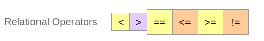

Exemplo:

```r
num1 = 15
num2 = 20

#equals to
num3=( num1 == num2 )
num3
```

```
## [1] FALSE
```

```r
#not equal to
num3= ( num1 != num2 )
num3
```

```
## [1] TRUE
```

```r
#lesser than
num3=  ( num1 < num2 )
num3
```

```
## [1] TRUE
```

```r
#less than equal to
num1 = 5
num2 = 20
num3 = ( num1 <= num2 )
num3
```

```
## [1] TRUE
```

## Operadores de Atribuição

Esses operadores são usados para atribuir valores a variáveis em R. A atribuição pode ser executada usando o operador de atribuição (<-) ou o operador igual (=). O valor da variável pode ser atribuído de duas formas, atribuição à esquerda e atribuição à direita.

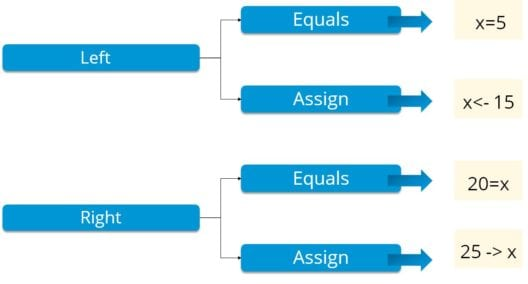

## Operadores Lógicos

Esses operadores comparam as duas entidades e são normalmente usados com valores booleanos (lógicos), como ‘e’, ‘ou’ e ‘não’.

# Expressões Condicionais

## if Statement

A instrução **if** ajuda você a avaliar uma única expressão como parte do fluxo. Para realizar essa avaliação, basta escrever a palavra-chave **if** seguida da expressão a ser avaliada. O diagrama de fluxo abaixo dará uma ideia de como a instrução **if** controla o fluxo de um código:

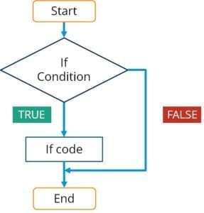

Exemplo:

```r
num1=10
num2=20

if(num1 <= num2){
print("Num1 is less or equal to Num2")
}
```

```
## [1] "Num1 is less or equal to Num2"
```

## Else If Statement

A instrução **Else if** ajuda você a estender ramificações para o fluxo criado pela instrução If e oferece a oportunidade de avaliar várias condições, criando novos ramos de fluxo. O fluxo abaixo lhe dará uma idéia de como a instrução else if ramifica o fluxo do código:

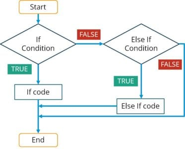

Exemplo:

```r
x <- 2
if (x ==1){
    print('same')
} else if (x > 1){
    print('bigger')
} else {
    print('smaller')
}
```

```
## [1] "bigger"
```

## Else Statement

A instrução else é usada quando todas as outras expressões são verificadas e consideradas inválidas. Esta será a última declaração executada como parte da ramificação If - Else if. Abaixo do fluxo, você terá uma ideia melhor de como o Else altera o fluxo do código:

[figure not shown]

Exemplo:

```r
x <- .5
if (x ==1){
    print('same')
} else if (x > 1){
    print('bigger')
} else {
    print('smaller')
}
```

```
## [1] "smaller"
```

# Loops

Uma declaração de loop nos permite executar uma instrução ou grupo de instruções várias vezes. Existem principalmente 3 tipos de loops em R.

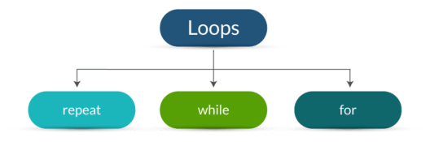

## Repeat

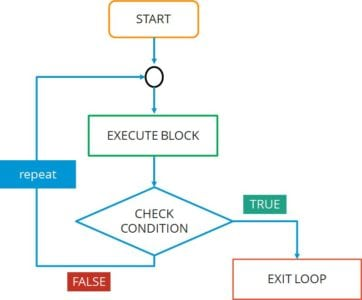

```r
x=2
repeat{
  x <- x^2
  print(x)
  if( x >100){
      break }}
```

```
## [1] 4
## [1] 16
## [1] 256
```

## While

Isso ajuda a repetir uma instrução ou grupo de instruções enquanto uma determinada condição é VERDADEIRA. Enquanto loop, quando comparado com o loop de repetição é um pouco diferente, é um exemplo de um loop de entrada controlada em que a condição é verificada primeiro e somente se a condição for verdadeira o controle será entregue dentro do loop para executar o código . Abaixo está o fluxo de controle em um loop while:

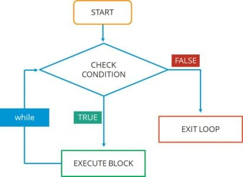

```r
num = 1
sumn = 0

while (num<= 11){
 sumn <- (sumn + (num^2))
 num = num+1
 print(sumn)
}
```

```
## [1] 1
## [1] 5
## [1] 14
## [1] 30
## [1] 55
## [1] 91
## [1] 140
## [1] 204
## [1] 285
## [1] 385
## [1] 506
```

## For

É usado para repetir uma declaração ou grupo de um número fixo de vezes. Ao contrário do loop repeat e while, o loop for é usado em situações em que estamos cientes do número de vezes que o código precisa ser executado de antemão. É semelhante ao loop while, onde a condição é verificada pela primeira vez e, em seguida, somente o código escrito dentro é executado. Vamos ver o fluxo de controle de for loop agora:

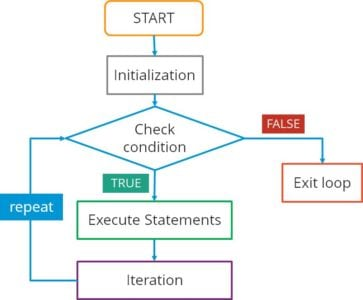

Vamos agora olhar para um exemplo em que estaremos usando o loop for para imprimir os primeiros 10 números:

```r
for(x in 1:10){
print(x)
}
```

```
## [1] 1
## [1] 2
## [1] 3
## [1] 4
## [1] 5
## [1] 6
## [1] 7
## [1] 8
## [1] 9
## [1] 10
```

# Funções

Uma função é um bloco de código organizado e reutilizável usado para executar ações relacionadas. Existem basicamente dois tipos de funções em R.

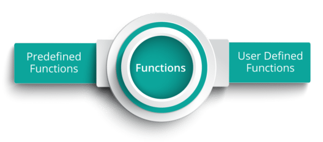

## Funções Predefidas

Estes são construídos em funções que podem ser usadas pelo usuário para facilitar seu trabalho. Por exemplo: mean(x), sum(x), sqrt(x), toupper(x), etc. Apresentam estrutura genérica dada por:

```r
nome(argumento1, argumento2, ...)
```

- Exemplo: função runif() (para gerar valores aleatórios de uma distribuição uniforme):

```r
runif(n, min = 0, max = 1)
```

Argumentos que já possuem um valor especificado (como max e min) podem ser omitidos:

```r
runif(10)
```

```r
runif(10, 1, 100)
```

```
##  [1] 69.168159  3.672403 94.800639 38.474884 50.966467 53.630031 83.440905
##  [8] 99.439949 12.881911 68.541620
```

Se os argumentos forem nomeados, a ordem deles dentro da função não tem mais importância:

```r
runif(min = 1, max = 100, n = 10)
```

Argumentos nomeados e não nomeados podem ser utilizados, desde que os não nomeados estejam na posição correta:

```r
runif(10, max = 100, min = 1)
```

- Exemplo: função sample():

```r
sample(x, size, replace = FALSE, prob = NULL)
```

x e size devem ser obrigatoriamente especificados, enquanto que replace é lógico: TRUE (T) ou FALSE (F).

prob é um argumento vazio ou ausente (“opcional”).

- Exemplo: função plot():

```r
plot(x, y, ...)
```

- “…” permite especificar argumentos de outras funções (por exemplo par())

### Mecanismos de ajuda

Argumentos e detalhes do funcionamento das funções:

```r
?runif
```

ou

```r
help(runif)
```

A documentação contém os campos:

- Description: breve descrição
- Usage: função e todos seus argumentos
- Arguments: lista descrevendo cada argumento
- Details: descrição detalhada
- Value: o que a função retorna
- References: bibliografia relacionada
- See Also: funções relacionadas
- Examples: exemplos práticos

## Funções Implementadas pelo usuário

Essas funções são criadas pelo usuário para atender a um requisito específico do usuário. O abaixo é a sintaxe para criar uma função em R.

### Criando uma Função

A ideia original do R é transformar usuários em programadores

Criar funções para realizar trabalhos específicos é um dos grandes poderes do R

Por exemplo, podemos criar a famosa função

```r
ola.mundo <- function(){
    writeLines("Olá mundo")
}
```

e chamá-la através de

```r
ola.mundo()
```

```
## Olá mundo
```

A função acima não permite alterar o resultado de saída. Podemos fazer isso incluindo um argumento

```r
ola.mundo <- function(texto){
    writeLines(texto)
}
```

E fazer por exemplo

```r
ola.mundo("Funções são legais")
```

```
## Funções são legais
```

```r
sum_of_squares <- function(x,y){
x^2 + y^2
}

sum_of_squares(3,4)
```

```
## [1] 25
```

### Exercícios

1. Usando a função runif() gere 30 números aleatórios entre:
- 0 e 1
- -5 e 5
- 10 e 500 alternando a posição dos argumentos da função.
2. Veja o help da função (?) “+”
3. Crie uma função para fazer a soma de dois números: x e y